# Case II — Smartphone Quality (Samsung Analysis)

Lina Simonian & Elena Pshenichnikova

2025-03-25

### **Introduction**

This project investigates how customers perceive the quality of **Samsung smartphones**, with the goal of identifying which specific dimensions of perceived quality most strongly influence their **willingness to pay a premium** and **intention to repurchase**.

> While product quality is widely recognized as a *multidimensional concept*, there is currently no consistent measurement scale that fully captures this complexity from the consumer’s perspective.

To address this gap, we focus exclusively on **Samsung users**, analyzing data from a larger survey of over **1,000 smartphone customers** in the United States. From this dataset, we isolated the responses of those who indicated that they use a Samsung smartphone. The survey includes **33 quality-related items**, developed through **qualitative interviews** and **expert validation**.

### **Question 1: Orthogonal Factor Analysis**

To begin the analysis, we first **cleaned the dataset** using **listwise deletion**, removing observations with any missing values in the relevant variables.

We then loaded all **required R packages**, including:

- `corrplot` – for correlation matrix visualization
- `olsrr` – for multicollinearity diagnostics (VIF and tolerance values)
- `REdaS` – for Bartlett’s test and KMO measure
- `psych` – for principal component analysis (PCA)

> Additionally, the dataset was uploaded to **GitHub**, ensuring collaborative access and making it easier to update the project, rerun the analysis, and track progress consistently across devices.

```r
# Сlear the database
rm(list=ls())
graphics.off()
```

```r
#Install necessary packages. Delete # sign in order to download all of them.
#install.packages('rcompanion', repos = "https://cloud.r-project.org")
#install.packages('nortest', repos = "https://cloud.r-project.org")
#install.packages('corrplot', repos = "https://cloud.r-project.org")
#install.packages('olsrr', repos = "https://cloud.r-project.org")
#install.packages('dplyr', repos = "https://cloud.r-project.org")
#install.packages('pastecs', repos = "https://cloud.r-project.org")
#install.packages('REdaS', repos = "https://cloud.r-project.org")
#install.packages('psych', repos = "https://cloud.r-project.org")
#install.packages('lm.beta', repos = "https://cloud.r-project.org")
```

```r
#install.packages("DT")
library(DT)

# Clear the database
rm(list=ls())

# Load required libraries
library(ggplot2)
library(dplyr)
library(readr)
library(broom)
library(lm.beta)
library(pastecs)
library(tidyr)
library(corrplot)     # For Сorrelation Matrix Visualization
library(olsrr)        # For VIF and tolerance values
library(REdaS)        # For Bartlett's test
library(psych)        # For PCA and KMO
```

```r
# Read the dataset directly from the provided URL
url <- "https://raw.githubusercontent.com/silinette/Case-Study-II/refs/heads/main/Data%20File_Case_Study_Factor%20Analysis_MD.csv"

Data <- read.csv(url, header = TRUE)
```

### **Data Structure Exploration**

In the next step, we examined the **structure of the dataset** to gain an initial understanding of the available information. We confirmed that the dataset contained **1,014 observations** and **74 variables**.

To ensure proper familiarity with the data, we performed the following steps: - Reviewed the **first few rows** of the dataset  
- Explored the **names of all variables**  
- Inspected the **data types** and **sample values** for each column

This exploratory step was essential to validate the integrity of the data before proceeding with any statistical analysis.

```r
# Explore the structure of the dataset
dim(Data) # Check the number of rows and columns in the dataset
```

```
## [1] 1014   74
```

```r
head(Data) # Display the first few rows of the dataset
```

```
##   ownership usage_freq usingSince typicalUse brand cost starRating intro_q qd1
## 1         1          2          4          4     1    1          3       1   3
## 2         1          2          3          3     1    1          4       1   4
## 3         1          2          5          4     1    1          4       1   3
## 4         1          2          4          4     1    2          4       1   5
## 5         1          2          5          4     1    1          4       1   4
## 6         1          2          5          4     1    2          3       1   3
##   qd2 qd3 qd4 qd5 qd6 qd7 qd8 qd9 qd10 qd11 qd12 qd13 qd14 qd15 qd16 qd17 qd18
## 1   4   3   3   4   3   4   3   3    3    3    3    4    3    3    4    3    3
## 2   4   3   6   4   4   4   4   4    4    3    4    4    4    4    4    4    4
## 3   4   3   2   3   3   3   4   3    3    4    5    3    3    3    4    3    3
## 4   5   4   3   5   5   5   5   4    5    5    5    5    4    4    4    5    4
## 5   4   5   2   3   3   4   4   3    4    5    4    4    3    4    3    4    4
## 6   4   3   5   3   3   4   3   3    3    3    4    3    3    4    4    3    3
##   qd19 qd20 qd21 qd22 qd23 qd24 qd25 qd26 qd27 qd28 qd29 qd30 qd31 qd32 qd33
```

[output cut: 34 more lines]

```r
str(Data) # Display the structure of the dataset (types, sample values)
```

```
## 'data.frame':    1014 obs. of  74 variables:
##  $ ownership       : int  1 1 1 1 1 1 1 1 1 1 ...
##  $ usage_freq      : int  2 2 2 2 2 2 2 2 2 4 ...
##  $ usingSince      : int  4 3 5 4 5 5 3 5 4 4 ...
##  $ typicalUse      : int  4 3 4 4 4 4 4 4 4 4 ...
##  $ brand           : int  1 1 1 1 1 1 1 1 1 1 ...
##  $ cost            : int  1 1 1 2 1 2 1 1 1 3 ...
##  $ starRating      : int  3 4 4 4 4 3 5 3 4 4 ...
##  $ intro_q         : int  1 1 1 1 1 1 1 1 1 1 ...
##  $ qd1             : int  3 4 3 5 4 3 4 3 4 4 ...
##  $ qd2             : int  4 4 4 5 4 4 5 3 4 5 ...
##  $ qd3             : int  3 3 3 4 5 3 5 4 5 3 ...
##  $ qd4             : int  3 6 2 3 2 5 2 2 2 5 ...
##  $ qd5             : int  4 4 3 5 3 3 5 3 4 4 ...
##  $ qd6             : int  3 4 3 5 3 3 3 3 3 3 ...
```

[output cut: 60 more lines]

```r
names(Data) # Show all variable names in the dataset
```

```
##  [1] "ownership"        "usage_freq"       "usingSince"       "typicalUse"
##  [5] "brand"            "cost"             "starRating"       "intro_q"
##  [9] "qd1"              "qd2"              "qd3"              "qd4"
## [13] "qd5"              "qd6"              "qd7"              "qd8"
## [17] "qd9"              "qd10"             "qd11"             "qd12"
## [21] "qd13"             "qd14"             "qd15"             "qd16"
## [25] "qd17"             "qd18"             "qd19"             "qd20"
## [29] "qd21"             "qd22"             "qd23"             "qd24"
## [33] "qd25"             "qd26"             "qd27"             "qd28"
## [37] "qd29"             "qd30"             "qd31"             "qd32"
## [41] "qd33"             "intro_b"          "wtp1"             "wtp2"
## [45] "wtp3"             "OQ1"              "OQ2"              "bc1"
## [49] "bc2"              "OQ3"              "ri1"              "ri2"
## [53] "bc3"              "bc4"              "sat3"             "sat2"
## [57] "OQ4"              "sat1"             "defect1"          "defectsFaced"
## [61] "noOfDefects"      "defectsWarranty"  "fRecall"          "def_sev1"
## [65] "def_sev2"         "didComplain"      "reactionComplain" "nextPurchase"
## [69] "intro_d"          "gender"           "age"              "education"
## [73] "income"           "brandrec"
```

### **Data Refinement and Cleaning**

At this stage, we refined the dataset by selecting only the variables essential for the analysis — specifically, **33 quality perception items** (`qd1` to `qd33`) and several outcome-related variables such as **brand recommendation**, **willingness to pay**, and **repurchase intentions** (`brandrec`, `wtp1`, `wtp2`, `wtp3`, `ri1`, `ri2`).

To maintain data consistency and integrity, we applied **listwise deletion**, excluding all observations that had missing values in any of the selected fields. This ensured that the resulting dataset was **clean**, **complete**, and suitable for conducting the factor analysis.

```r
# Select only variables needed for the analysis
Data <- Data %>%
  select(
    qd1, qd2, qd3, qd4, qd5, qd6, qd7, qd8, qd9,
    qd10, qd11, qd12, qd13, qd14, qd15, qd16, qd17, qd18, qd19,
    qd20, qd21, qd22, qd23, qd24, qd25, qd26, qd27, qd28, qd29,
    qd30, qd31, qd32, qd33,
    brandrec, wtp1, wtp2, wtp3, ri1, ri2
  )
# Check for missing values
list_na <- colnames(Data)[apply(Data, 2, anyNA)] # Identify columns with missing values
list_na
```

```
## [1] "qd22" "qd26" "qd28" "qd29" "qd31" "qd33"
```

```r
sum(is.na(Data)) # Count total number of missing values
```

```
## [1] 270
```

```r
sum(!is.na(Data)) # Count total number of non-missing values
```

```
## [1] 39276
```

```r
# Remove all rows with missing values (listwise deletion)
Data_clean <- na.omit(Data)

#IMPORTANT! We select only our brand. In our case is Samsung = 2.
Data_clean <- Data_clean %>% filter(brandrec == 2)

# Сheck structure and dimensions of the new dataset
str(Data_clean)
```

```
## 'data.frame':    234 obs. of  39 variables:
##  $ qd1     : int  3 3 1 5 3 3 5 3 4 4 ...
##  $ qd2     : int  3 4 1 5 3 3 5 3 5 3 ...
##  $ qd3     : int  3 4 4 5 3 2 4 3 4 3 ...
##  $ qd4     : int  3 2 3 2 5 3 5 5 4 5 ...
##  $ qd5     : int  3 2 1 5 2 3 5 4 4 3 ...
##  $ qd6     : int  3 2 1 5 3 2 5 3 4 3 ...
##  $ qd7     : int  3 4 1 5 3 2 5 4 5 4 ...
##  $ qd8     : int  3 3 1 5 3 3 5 4 5 3 ...
##  $ qd9     : int  4 3 1 5 3 2 4 4 3 4 ...
##  $ qd10    : int  4 3 1 5 3 3 5 5 4 4 ...
##  $ qd11    : int  4 4 4 5 3 2 4 3 4 3 ...
##  $ qd12    : int  3 4 1 5 3 2 5 4 5 3 ...
##  $ qd13    : int  3 4 2 5 3 3 4 4 4 3 ...
##  $ qd14    : int  3 3 1 5 3 3 4 3 3 4 ...
```

[output cut: 27 more lines]

```r
dim(Data_clean)
```

```
## [1] 234  39
```

```r
sum(is.na(Data_clean))
```

```
## [1] 0
```

```r
#write.csv(Data_clean, file = "~/Desktop/Data_clean.csv", row.names = FALSE)
```

### **Descriptive Statistics**

We then performed descriptive statistical analysis for the 33 quality-related survey items.  
This step provided summary statistics such as the **mean**, **standard deviation**, **minimum**, and **maximum** values for each item. These indicators offer a first look into the **distribution** and **variability** of participants’ responses.  
Normality testing was intentionally excluded due to the **ordinal nature of Likert-scale data**.

```r
# Descriptive statistics for 33 quality-related variables
round(stat.desc(Data_clean[, paste0("qd", 1:33)]), digits = 2)
```

```
##                 qd1    qd2    qd3    qd4    qd5    qd6    qd7    qd8    qd9
## nbr.val      234.00 234.00 234.00 234.00 234.00 234.00 234.00 234.00 234.00
## nbr.null       0.00   0.00   0.00   0.00   0.00   0.00   0.00   0.00   0.00
## nbr.na         0.00   0.00   0.00   0.00   0.00   0.00   0.00   0.00   0.00
## min            1.00   1.00   2.00   1.00   1.00   1.00   1.00   1.00   1.00
## max            5.00   5.00   5.00   7.00   5.00   5.00   5.00   5.00   5.00
## range          4.00   4.00   3.00   6.00   4.00   4.00   4.00   4.00   4.00
## sum          933.00 959.00 913.00 858.00 892.00 854.00 966.00 908.00 887.00
## median         4.00   4.00   4.00   4.00   4.00   4.00   4.00   4.00   4.00
## mean           3.99   4.10   3.90   3.67   3.81   3.65   4.13   3.88   3.79
## SE.mean        0.06   0.06   0.05   0.09   0.07   0.06   0.05   0.06   0.05
## CI.mean.0.95   0.11   0.11   0.10   0.19   0.13   0.12   0.10   0.11   0.11
## var            0.72   0.73   0.66   2.09   1.03   0.90   0.64   0.76   0.68
## std.dev        0.85   0.86   0.81   1.44   1.01   0.95   0.80   0.87   0.83
## coef.var       0.21   0.21   0.21   0.39   0.27   0.26   0.19   0.22   0.22
##                qd10   qd11   qd12   qd13   qd14   qd15   qd16   qd17   qd18
## nbr.val      234.00 234.00 234.00 234.00 234.00 234.00 234.00 234.00 234.00
## nbr.null       0.00   0.00   0.00   0.00   0.00   0.00   0.00   0.00   0.00
## nbr.na         0.00   0.00   0.00   0.00   0.00   0.00   0.00   0.00   0.00
## min            1.00   1.00   1.00   2.00   1.00   1.00   1.00   1.00   1.00
## max            5.00   5.00   5.00   5.00   5.00   5.00   5.00   5.00   5.00
## range          4.00   4.00   4.00   3.00   4.00   4.00   4.00   4.00   4.00
## sum          945.00 905.00 972.00 951.00 879.00 896.00 921.00 880.00 797.00
## median         4.00   4.00   4.00   4.00   4.00   4.00   4.00   4.00   3.00
## mean           4.04   3.87   4.15   4.06   3.76   3.83   3.94   3.76   3.41
## SE.mean        0.05   0.06   0.06   0.05   0.05   0.06   0.06   0.06   0.06
## CI.mean.0.95   0.11   0.11   0.11   0.10   0.11   0.11   0.12   0.11   0.11
## var            0.71   0.72   0.77   0.57   0.67   0.76   0.84   0.72   0.77
## std.dev        0.84   0.85   0.88   0.75   0.82   0.87   0.92   0.85   0.88
## coef.var       0.21   0.22   0.21   0.19   0.22   0.23   0.23   0.22   0.26
##                qd19   qd20   qd21   qd22   qd23   qd24   qd25   qd26   qd27
## nbr.val      234.00 234.00 234.00 234.00 234.00 234.00 234.00 234.00 234.00
## nbr.null       0.00   0.00   0.00   0.00   0.00   0.00   0.00   0.00   0.00
## nbr.na         0.00   0.00   0.00   0.00   0.00   0.00   0.00   0.00   0.00
## min            1.00   1.00   1.00   1.00   1.00   1.00   1.00   1.00   1.00
## max            5.00   5.00   5.00   5.00   7.00   5.00   5.00   5.00   5.00
## range          4.00   4.00   4.00   4.00   6.00   4.00   4.00   4.00   4.00
## sum          890.00 959.00 891.00 942.00 853.00 887.00 864.00 877.00 962.00
## median         4.00   4.00   4.00   4.00   4.00   4.00   4.00   4.00   4.00
## mean           3.80   4.10   3.81   4.03   3.65   3.79   3.69   3.75   4.11
## SE.mean        0.06   0.05   0.06   0.06   0.10   0.05   0.06   0.06   0.05
## CI.mean.0.95   0.11   0.10   0.11   0.12   0.20   0.11   0.12   0.11   0.10
## var            0.73   0.61   0.73   0.87   2.38   0.69   0.87   0.76   0.65
## std.dev        0.86   0.78   0.86   0.94   1.54   0.83   0.94   0.87   0.81
## coef.var       0.23   0.19   0.22   0.23   0.42   0.22   0.25   0.23   0.20
##                qd28   qd29   qd30   qd31   qd32   qd33
## nbr.val      234.00 234.00 234.00 234.00 234.00 234.00
## nbr.null       0.00   0.00   0.00   0.00   0.00   0.00
## nbr.na         0.00   0.00   0.00   0.00   0.00   0.00
## min            1.00   1.00   1.00   1.00   2.00   1.00
## max            5.00   5.00   5.00   5.00   5.00   5.00
## range          4.00   4.00   4.00   4.00   3.00   4.00
## sum          827.00 937.00 943.00 862.00 898.00 919.00
## median         3.00   4.00   4.00   4.00   4.00   4.00
## mean           3.53   4.00   4.03   3.68   3.84   3.93
## SE.mean        0.06   0.06   0.05   0.05   0.05   0.06
## CI.mean.0.95   0.11   0.12   0.10   0.11   0.10   0.12
## var            0.74   0.83   0.62   0.68   0.62   0.88
## std.dev        0.86   0.91   0.79   0.83   0.79   0.94
## coef.var       0.24   0.23   0.20   0.22   0.20   0.24
```

```r
# Descriptive statistics (mean, standard deviation, min, max, etc.) for the 33 quality-related survey items (qd1 to qd33) from the cleaned dataset. The results are rounded to 2 decimal places for readability.

# Normality test not included (norm = TRUE) because Likert-scale items are not truly continuous.
```

### **Visualization of Response Distributions**

In this step, the dataset was reshaped into long format to facilitate item-wise visualization of survey responses.  
Each row now represents a single response to a specific item. To ensure correct ordering of the **Likert-scale values** in the plots, responses were converted into **ordered factors**.

Subsequently, **bar charts** were created for each of the 33 quality-related items, illustrating the **frequency distribution** of responses across participants.

```r
# Reshape only qd1 to qd33 into long format for visualization
data_long <- Data_clean %>%
  select(paste0("qd", 1:33)) %>%  # Use only quality-related survey items
  pivot_longer(everything(), names_to = "Item", values_to = "Response")  # Convert from wide to long format

# Order items numerically (qd1 to qd33) instead of alphabetically
data_long$Item <- factor(data_long$Item, levels = paste0("qd", 1:33))

# Preview reshaped data
head(data_long) # Show the first few rows of the long-format data to check the transformation
```

```
## # A tibble: 6 × 2
##   Item  Response
##   <fct>    <int>
## 1 qd1          3
## 2 qd2          3
## 3 qd3          3
## 4 qd4          3
## 5 qd5          3
## 6 qd6          3
```

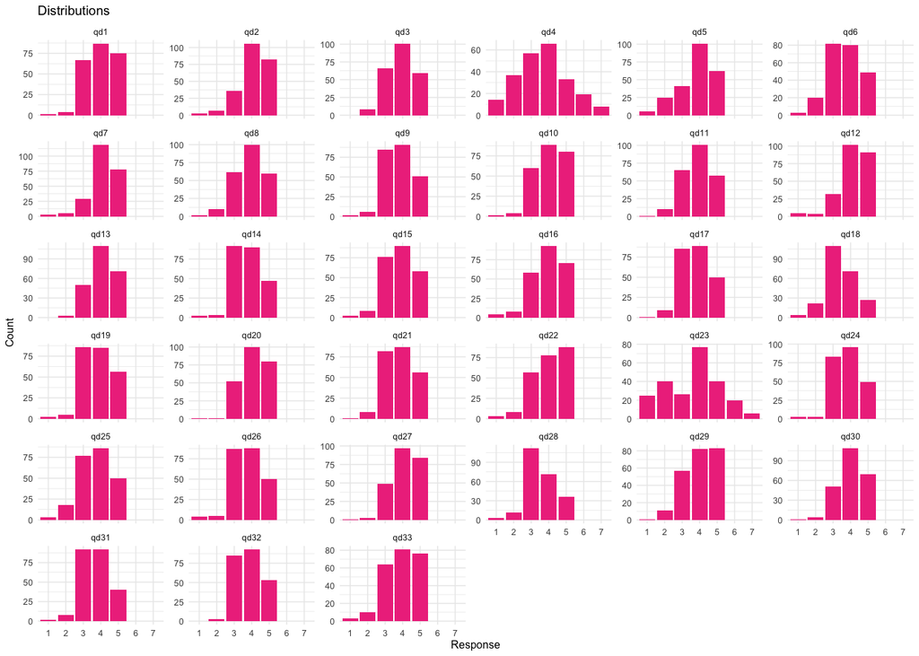

```r
# Convert responses to ordered factor
data_long$Response <- factor(data_long$Response, levels = sort(unique(unlist(Data_clean)))) # Convert all numeric responses into an ordered factor to preserve Likert scale order in plots

# Plot response distributions for all items (directly in R Markdown)
ggplot(data_long, aes(x = Response)) + # Set x-axis to response values
  geom_bar(fill = "violetred2") + # Create bar charts
  facet_wrap(~ Item, scales = "free_y") + # One plot per item
  labs(title = "Distributions", x = "Response", y = "Count") + # Title and axis labels
  theme_minimal(base_size = 6)  # Clean theme
```

###**Visual Inspection of Response Distributions**

By inspecting these distributions, we can preliminarily assess **data suitability** for factor analysis and detect any **floor or ceiling effects** that could impact the results.

###**Correlation Matrix** The correlation matrix shows how strongly each of the 33 quality-related survey items is **linearly** related to the others. It helps identify clusters of items that may measure the same underlying dimension of perceived quality, serving as a foundation for factor analysis

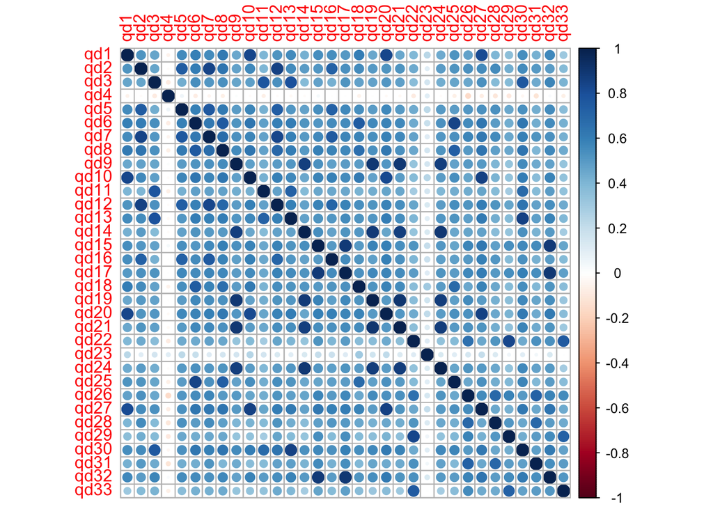

```r
# Calculate and visualize correlation matrix
raqMatrix <- cor(Data_clean[, paste0("qd", 1:33)])
corrplot(as.matrix(raqMatrix))
```

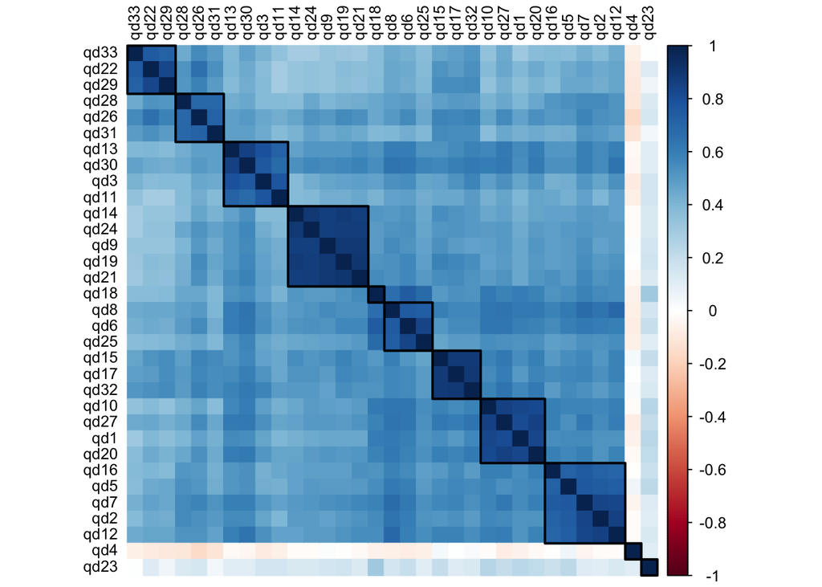

```r
# Calculate correlation matrix
raqMatrix <- cor(Data_clean[, paste0("qd", 1:33)])

# Visualize with hierarchical clustering (group similar items together)
corrplot(as.matrix(raqMatrix),
         method = "color",      # Цветовая шкала
         order = "hclust",      # Упорядочивание по кластерному анализу
         tl.col = "black",      # Цвет подписей
         tl.cex = 0.8,          # Размер подписей
         addrect = 11)           # Нарисовать прямоугольники для кластеров (можно поменять 4 на другое число)
```

#Bartlett’s Test и KMO

```r
# Run Bartlett's test of sphericity
bart_spher(Data_clean[, paste0("qd", 1:33)])
```

```
##  Bartlett's Test of Sphericity
##
## Call: bart_spher(x = Data_clean[, paste0("qd", 1:33)])
##
##      X2 = 8303.442
##      df = 528
## p-value < 2.22e-16
```

```r
#KMO Criterion
kmo_test <- KMOS(Data_clean[, paste0("qd", 1:33)])
kmo_test$KMO           # Overall KMO measure
```

```
## [1] 0.9493879
```

```r
#Anti-Image Correlations
sort(kmo_test$MSA)     # Measure of sampling adequacy for each item
```

```
##       qd4      qd23      qd22      qd33      qd15      qd31      qd29       qd3
## 0.5150208 0.7005361 0.9160662 0.9209038 0.9306456 0.9339232 0.9343306 0.9357674
##      qd25      qd11      qd17       qd6      qd27      qd14       qd9      qd32
## 0.9360333 0.9412347 0.9422133 0.9443991 0.9461158 0.9469405 0.9470609 0.9518103
##      qd21      qd24      qd12       qd2       qd1      qd13      qd19      qd10
## 0.9531551 0.9545390 0.9558284 0.9559195 0.9567969 0.9571001 0.9574717 0.9577373
##      qd28      qd18      qd20       qd5      qd26      qd30       qd7      qd16
## 0.9579630 0.9607240 0.9611698 0.9627443 0.9634317 0.9635712 0.9637861 0.9654514
##       qd8
## 0.9666239
```

**Bartlett’s Test of Sphericity** checks if the correlation matrix is an identity matrix (no relationships between variables). A significant result (p < 0.05) means the variables do have meaningful correlations, which supports using factor analysis or PCA.

**Kaiser–Meyer–Olkin (KMO) Measure** assesses the adequacy of sampling for factor analysis by examining how patterns of correlations are relatively compact. The KMO value ranges from 0 to 1, where a value closer to 1 indicates that a factor analysis is appropriate. A KMO of 0.9493879 is considered excellent, suggesting that the data are highly suitable for factor analysis or PCA.

### Scree Plot

```r
# Running PCA without rotation for scree plot analysis
PC0 <- principal(Data_clean[, paste0("qd", 1:33)],
                 rotate = "none")
PC0$values #Eigenvalues
```

```
##  [1] 17.05989906  2.26471095  1.95137861  1.45118526  1.33752863  1.18386584
##  [7]  0.99427082  0.96452103  0.81708634  0.72349044  0.39108602  0.34887812
## [13]  0.33664348  0.30662204  0.28947810  0.26013919  0.25215032  0.22886912
## [19]  0.20491829  0.18769717  0.17020171  0.15029482  0.14652118  0.14064337
## [25]  0.13268775  0.12068080  0.11054309  0.09453646  0.08827591  0.08487528
## [31]  0.07321202  0.06785120  0.06525757
```

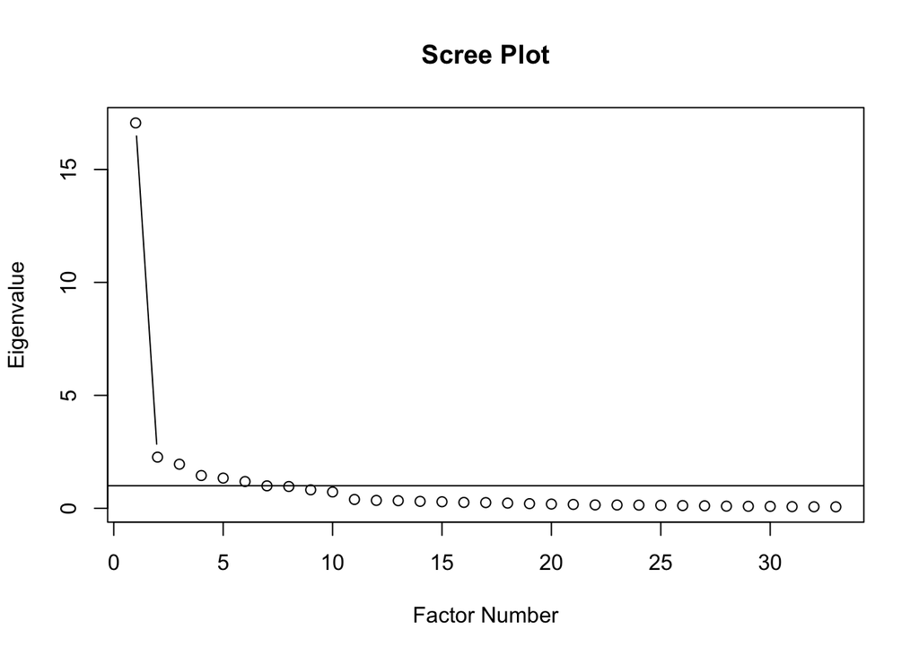

```r
# Scree plot of eigenvalues
plot(PC0$values, type = "b", main = "Scree Plot", xlab = "Factor Number", ylab = "Eigenvalue")
abline(h = 1) # Kaiser criterion line
```

```r
# Extraction and displaying communalities
PC0_communalities <- data.frame(sort(PC0$communality))
PC0_communalities
```

```
##      sort.PC0.communality.
## qd4            0.002875127
## qd23           0.046607469
## qd33           0.343753689
## qd29           0.382545259
## qd22           0.397378824
## qd11           0.405983279
## qd31           0.437926019
## qd28           0.444135519
## qd3            0.489144652
## qd25           0.505671434
## qd14           0.512721544
## qd1            0.541460536
## qd9            0.542653060
## qd18           0.543831785
## qd24           0.546816131
## qd26           0.547983655
## qd16           0.553439095
## qd5            0.573475488
## qd19           0.575354079
## qd10           0.587487336
## qd21           0.587742850
## qd13           0.588115029
## qd2            0.592204759
## qd15           0.608298798
## qd17           0.610703847
## qd20           0.616454068
## qd32           0.619142428
## qd6            0.633573132
## qd12           0.640601821
## qd30           0.640722300
## qd27           0.641355019
## qd8            0.641904515
## qd7            0.657836519
```